# semantic_segmentation

## Multi-class Land Use Type Segmentation based on UNet

Xiaoyi Wu

### 1. Introduction

land use is the expression of ecological resources and human activities dominating different areas of the Earth’s surface. Accurate and efficient identification of land use type is critical for sustainable development, natural hazard monitoring and risk prediction.

Semantic segmentation is a process of pixel-level classification of remote sensing images. Unet is a convolutional network architecture prsposed by Ronneberger et al. in 2015 for biomedical image semantic segmentation. Since its good performance in detecting irregular shape, Unet is widely applied various areas such as autonomous dribing, agriculture, and land use type classification. Unet is composed of encoder and decoder, which gives it the u-shape architecture. The encoder uses convoltion and pooling layers to reduce image dimension.The decoder uses transposed convolution and concatenation to recover high-resolution image details.

This project utilizes UNet to classify the land use type for remote sensing images based on pixel level.

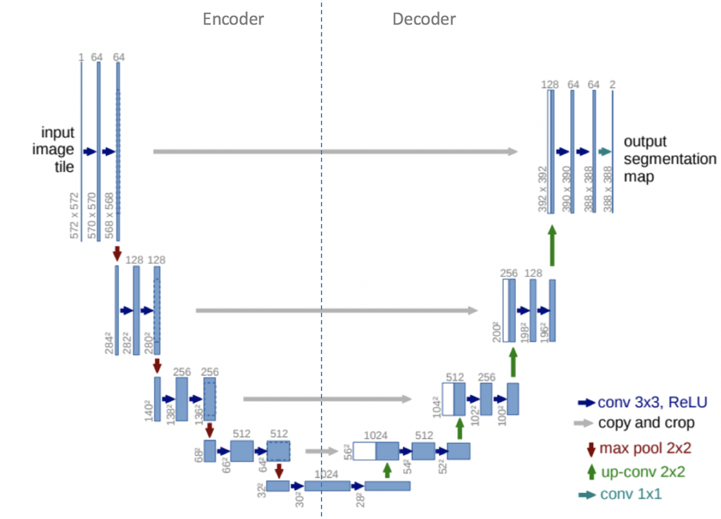

```python
import argparse
import csv
import time
import sys
import os
from zipfile import ZipFile
from google.colab import drive

# other library
import numpy as np
import pandas as pd
from PIL import Image
import glob
import matplotlib.image as mpimg
import json

# PyTorch library
import torch
import torch.nn as nn
import torch.nn.functional as F
import torch.optim as optim
from torch.utils import data
import numpy as np
import random
from scipy import misc
from PIL import Image
import matplotlib.pyplot as plt
from torch.utils.data import Dataset
import cv2
from torch.nn import ConvTranspose2d
from torch.nn import Conv2d
from torch.nn import MaxPool2d
from torch.nn import Dropout,CrossEntropyLoss

from torchvision.transforms import CenterCrop
from torch.nn import functional as F
import torch

import torch

from torch.utils.data import DataLoader
import torchvision.transforms as transforms

from torch import nn
import torch.nn.functional as F

from torch.optim import Adam, AdamW

from scipy.cluster.vq import vq, kmeans

import pandas as pd

import pdb  # use pdb.set_trace() to set breakpoints for debugging
from sklearn.model_selection import train_test_split
```

##### hyperparameter

```python
# hyperparameter
drive.mount('/content/drive/')
path = "/content/drive/MyDrive/segmentation/"
NUM_EPOCHS = 40
input_height = 2048
input_width = 2048
class_number = 7
batch_size = 32
model_path = path+"model/"
plot_path = path+"plot/"
crop_size = 512
if  torch.cuda.is_available():
    device = torch.device("cuda")
else:
    device = torch.device("cpu")
```

##### Helper function

```python
# set random seed
def same_seeds(seed):
    # Python built-in random module
    random.seed(seed)
    # Numpy
    np.random.seed(seed)
    # Torch
    torch.manual_seed(seed)
    if torch.cuda.is_available():
        torch.cuda.manual_seed(seed)
        torch.cuda.manual_seed_all(seed)
    torch.backends.cudnn.benchmark = False
    torch.backends.cudnn.deterministic = True

same_seeds(19530615)
```

```python
# visualization function
def visualize(**images):
    n_images = len(images)
    plt.figure(figsize=(16,16))
    for idx, (name, image) in enumerate(images.items()):
        plt.subplot(1, n_images, idx + 1)
        plt.title(name.replace('_',' ').title(), fontsize=20)
        if type(image) == str:
            image = mpimg.imread(image)
        plt.imshow(image)
    plt.show()
```

### 2. Data

This original dataset was obtain from the [DeepGlobe Land Cover Classification Dataset](https://www.kaggle.com/datasets/balraj98/deepglobe-land-cover-classification-dataset) on Kaggle. It contains 803 satellite images. Each image has 2448*244 pixels with GRB channels and is paired with a same-size mask image for land use annotation. There are 7 classes in the dataset, using color-coding (R, G, B) as follows.

1. Urban land: 【0,255,255】 - Man-made, built up areas with human artifacts (can ignore roads for now which is hard to label)
2. Agriculture land: 【255,255,0】 - Farms, any planned (i.e. regular) plantation, cropland, orchards, vineyards, nurseries, and ornamental horticultural areas; confined feeding operations.
3. Rangeland: 【255,0,255】 - Any non-forest, non-farm, green land, grass
4. Forest land: 【0,255,0】 - Any land with x% tree crown density plus clearcuts.
5. Water: 【0,0,255】 - Rivers, oceans, lakes, wetland, ponds.
6. Barren land: 【255,255,255】 - Mountain, land, rock, dessert, beach, no vegetation
7. Unknown: 【0,0,0】 - Clouds and others

In the data processing, each image with paired mask is cropped to 9 images at 512*512 resolution for data augmentation, and images are normalized with a 0.5 mean and 0.5 standard deviation. And the whole dataset is divided into testing dataset and training dataset with the ratio of 3:7.

```python
## Classes and their RGB values
class_dict = pd.read_csv(path+'class_dict.csv')
class_name = class_dict['name'].values.tolist()
colors =np.array( class_dict[['r', 'g', 'b']].values.tolist())
class_number = len(class_name)

print('Class Names: ', class_name)
print("class number: ", class_number)
```

[output not shown]

```python
# Load metadata file
metadata = pd.read_csv(path+'metadata.csv')
data = metadata[metadata['split']=='train']

# Split train/test data with the ratio of 3:7
train, test = train_test_split(data, test_size=0.3)
train.head()
```

|  | image_id | split | sat_image_path | mask_path |
| --- | --- | --- | --- | --- |
| 99 | 208495 | train | train/208495_sat.jpg | train/208495_mask.png |
| 181 | 300626 | train | train/300626_sat.jpg | train/300626_mask.png |
| 595 | 757745 | train | train/757745_sat.jpg | train/757745_mask.png |
| 104 | 210473 | train | train/210473_sat.jpg | train/210473_mask.png |
| 301 | 434243 | train | train/434243_sat.jpg | train/434243_mask.png |

```python
train_image_path = train["sat_image_path"].to_list()
train_mask_path = train["mask_path"].to_list()
test_image_path = test["sat_image_path"].to_list()
test_mask_path = test["mask_path"].to_list()
```

```python
class MyDataset(Dataset):
    def __init__(self, origin_image, origin_mask, transforms=None):
        self.origin_image = origin_image
        self.origin_mask = origin_mask

        self.transforms = transforms

    def __len__(self):
        return len(self.origin_image) * 9

    def __getitem__(self, index):
        index = index // 9
        patch = index % 9

        image = cv2.imread(path+self.origin_image[index])
        mask = cv2.imread(path+self.origin_mask[index])
        image = cv2.cvtColor(image, cv2.COLOR_BGR2RGB)
        mask = cv2.cvtColor(mask, cv2.COLOR_BGR2RGB)

        # subsample
        i = patch // 3
        j = patch % 3

        transformed_image = np.zeros((crop_size,crop_size,3),dtype = np.uint8)
        transformed_mask = np.zeros((crop_size,crop_size),dtype=np.uint8)
        transformed_image[:, :, :] = image[i*crop_size:(i+1)*crop_size, j*crop_size:(j+1)*crop_size, :]
        for label, color in enumerate(colors):
            transformed_mask[:,:][np.all(mask[i*crop_size:(i+1)*crop_size, j*crop_size:(j+1)*crop_size,:]==color, axis=-1)] = label

        x = transformed_image
        y = transformed_mask
        if self.transforms:
            x = transforms.ToTensor()(x)
            image = transforms.Normalize(0.5, 0.5)(x)
            mask = torch.LongTensor(y)
        return image, mask
```

```python
# preparing dataset and dataloader
trainDS = MyDataset(train_image_path, train_mask_path,
  transforms=True)
testDS = MyDataset(test_image_path, test_mask_path,
    transforms=True)
trainLoader= DataLoader(trainDS, batch_size= batch_size, shuffle=True, num_workers=8)
testLoader= DataLoader(testDS, batch_size = batch_size, shuffle=True, num_workers=8)
```

### 3. Constructing UNet

Unet employs an encoder-decorder architecture. The encoder consists of maxpooling and downsample layers to extract image to low-dimension representation, while the decoder uses upsampling layers to project the low-dimension features into high-dimension space. Particularly, the decoder will project the low-dimension feature to its original size and concatenate the restored features with original martrix from encoder together as the input the next layer avoid information loss.

```python
class conv_block(nn.Module):
    def __init__(self, in_c, out_c):
        super().__init__()
        self.conv1 = nn.Conv2d(in_c, out_c, kernel_size=3, padding=1)
        self.bn1 = nn.BatchNorm2d(out_c)
        self.conv2 = nn.Conv2d(out_c, out_c, kernel_size=3, padding=1)
        self.bn2 = nn.BatchNorm2d(out_c)
        self.relu = nn.ReLU()

    def forward(self, inputs):
        x = self.conv1(inputs)
        x = self.bn1(x)
        x = self.relu(x)
        x = self.conv2(x)
        x = self.bn2(x)
        x = self.relu(x)
        return x

class encoder_block(nn.Module):
    def __init__(self, in_c, out_c):
        super().__init__()
        self.conv = conv_block(in_c, out_c)
        self.pool = nn.MaxPool2d((2, 2))

    def forward(self, inputs):
        x = self.conv(inputs)
        p = self.pool(x)
        return x, p

class decoder_block(nn.Module):
    def __init__(self, in_c, out_c):
        super().__init__()
        self.up = nn.ConvTranspose2d(in_c, out_c, kernel_size=2, stride=2, padding=0)
        self.conv = conv_block(out_c+out_c, out_c)

    def forward(self, inputs, skip):
        x = self.up(inputs)
        x = torch.cat([x, skip], axis=1)
        x = self.conv(x)
        return x
```

```python
class UNet(nn.Module):
    def __init__(self):
        super().__init__()

        """ Encoder """
        self.e1 = encoder_block(3, 8)
        self.e2 = encoder_block(8, 64)
        self.e3 = encoder_block(64, 128)
        self.e4 = encoder_block(128, 256)

        """ Bottleneck """
        self.b = conv_block(256, 512)

        """ Decoder """
        self.d1 = decoder_block(512, 256)
        self.d2 = decoder_block(256, 128)
        self.d3 = decoder_block(128, 64)
        self.d4 = decoder_block(64, 8)

        """ Classifier """
        self.outputs = nn.Conv2d(8, class_number, kernel_size=1, padding=0)

    def forward(self, inputs):

        """ Encoder """
        s1, p1 = self.e1(inputs)
        s2, p2 = self.e2(p1)
        s3, p3 = self.e3(p2)
        s4, p4 = self.e4(p3)

        """ Bottleneck """
        b = self.b(p4)

        """ Decoder """
        d1 = self.d1(b, s4)
        d2 = self.d2(d1, s3)
        d3 = self.d3(d2, s2)
        d4 = self.d4(d3, s1)

        """ Classifier """
        outputs = self.outputs(d4)

        return outputs
```

```python
# initialize our UNet model
# unet = torch.load(path+"model/1669078539.0762324_best_model.pt",
#                   map_location = device)
unet = UNet()
unet.to(device)
# initialize loss function and optimizer
lossFunc = CrossEntropyLoss()
opt = Adam(unet.parameters(), lr=1e-3)
scheduler = torch.optim.lr_scheduler.ReduceLROnPlateau(opt, 'min')
# calculate steps per epoch for training and test set
trainSteps = len(trainDS) // batch_size
testSteps = len(testDS) // batch_size
# initialize a dictionary to store training history
H = {"train_loss": [], "test_loss": [], "train_accuracy":[], "test_accuracy":[]}
```

```python
unet
```

```
UNet(
  (e1): encoder_block(
    (conv): conv_block(
      (conv1): Conv2d(3, 8, kernel_size=(3, 3), stride=(1, 1), padding=(1, 1))
      (bn1): BatchNorm2d(8, eps=1e-05, momentum=0.1, affine=True, track_running_stats=True)
      (conv2): Conv2d(8, 8, kernel_size=(3, 3), stride=(1, 1), padding=(1, 1))
      (bn2): BatchNorm2d(8, eps=1e-05, momentum=0.1, affine=True, track_running_stats=True)
      (relu): ReLU()
    )
    (pool): MaxPool2d(kernel_size=(2, 2), stride=(2, 2), padding=0, dilation=1, ceil_mode=False)
  )
  (e2): encoder_block(
    (conv): conv_block(
      (conv1): Conv2d(8, 64, kernel_size=(3, 3), stride=(1, 1), padding=(1, 1))
      (bn1): BatchNorm2d(64, eps=1e-05, momentum=0.1, affine=True, track_running_stats=True)
      (conv2): Conv2d(64, 64, kernel_size=(3, 3), stride=(1, 1), padding=(1, 1))
      (bn2): BatchNorm2d(64, eps=1e-05, momentum=0.1, affine=True, track_running_stats=True)
      (relu): ReLU()
    )
    (pool): MaxPool2d(kernel_size=(2, 2), stride=(2, 2), padding=0, dilation=1, ceil_mode=False)
  )
  (e3): encoder_block(
    (conv): conv_block(
      (conv1): Conv2d(64, 128, kernel_size=(3, 3), stride=(1, 1), padding=(1, 1))
      (bn1): BatchNorm2d(128, eps=1e-05, momentum=0.1, affine=True, track_running_stats=True)
      (conv2): Conv2d(128, 128, kernel_size=(3, 3), stride=(1, 1), padding=(1, 1))
      (bn2): BatchNorm2d(128, eps=1e-05, momentum=0.1, affine=True, track_running_stats=True)
      (relu): ReLU()
    )
    (pool): MaxPool2d(kernel_size=(2, 2), stride=(2, 2), padding=0, dilation=1, ceil_mode=False)
  )
  (e4): encoder_block(
    (conv): conv_block(
      (conv1): Conv2d(128, 256, kernel_size=(3, 3), stride=(1, 1), padding=(1, 1))
      (bn1): BatchNorm2d(256, eps=1e-05, momentum=0.1, affine=True, track_running_stats=True)
      (conv2): Conv2d(256, 256, kernel_size=(3, 3), stride=(1, 1), padding=(1, 1))
      (bn2): BatchNorm2d(256, eps=1e-05, momentum=0.1, affine=True, track_running_stats=True)
      (relu): ReLU()
    )
    (pool): MaxPool2d(kernel_size=(2, 2), stride=(2, 2), padding=0, dilation=1, ceil_mode=False)
```

[output cut: 35 more lines]

```
      (relu): ReLU()
    )
  )
  (d4): decoder_block(
    (up): ConvTranspose2d(64, 8, kernel_size=(2, 2), stride=(2, 2))
    (conv): conv_block(
      (conv1): Conv2d(16, 8, kernel_size=(3, 3), stride=(1, 1), padding=(1, 1))
      (bn1): BatchNorm2d(8, eps=1e-05, momentum=0.1, affine=True, track_running_stats=True)
      (conv2): Conv2d(8, 8, kernel_size=(3, 3), stride=(1, 1), padding=(1, 1))
      (bn2): BatchNorm2d(8, eps=1e-05, momentum=0.1, affine=True, track_running_stats=True)
      (relu): ReLU()
    )
  )
  (outputs): Conv2d(8, 7, kernel_size=(1, 1), stride=(1, 1))
)
```

### Training Process

In the training process, we use multi-class cross entropy as the loss function and Adam as the optimizer.

```python
# loop over epochs
print("[INFO] training the network...")
startTime = time.time()
best_loss = np.inf

for epoch in (range(NUM_EPOCHS)):
	print("epoch ", epoch)
	unet.train()
	totalTrainLoss = 0
	totalTestLoss = 0
	totalTrainAccuracy = 0
	totalTestAccuracy =0

	for (i, (x, y)) in enumerate(trainLoader): # get batch of training data
		# print("epoch",i)
		(x, y) = (x.to(device), y.to(device))
		pred = unet(x)
		loss = lossFunc(pred, y)
		# print("loss ", loss.item())
		opt.zero_grad() # zero the optimizer's gradient
		loss.backward()
		opt.step() # tell the optimizer to adjust weights in one step
		tmp_pred = np.argmax(pred.detach().cpu().numpy(), 1)
		tmp_y = y.detach().cpu().numpy()
		totalTrainLoss += loss.item()
		totalTrainAccuracy += (tmp_y[:,:,:] == tmp_pred[:,:,:]).sum()/tmp_y.size

	#average accuracy in one step
	averageTrainAccuray = totalTrainAccuracy / trainSteps
	avgTrainLoss = totalTrainLoss / trainSteps

	if avgTrainLoss<best_loss:
		best_loss = avgTrainLoss
		torch.save(unet,model_path+ str(startTime)+'_best_model.pt')

	torch.save(unet, model_path+str(startTime)+'_last_model.pt')

	with torch.no_grad():
		unet.eval()
		for (i, (x, y)) in enumerate(testLoader):
			(x, y) = (x.to(device), y.to(device))
			pred = unet(x)
			tmp_y = y.detach().cpu().numpy()
			tmp_pred =np.argmax(pred.detach().cpu().numpy(), 1)
			totalTestLoss += lossFunc(pred, y).item()
			totalTestAccuracy += (tmp_y[:,:,:] == tmp_pred[:,:,:]).sum()/tmp_y.size

		averageTestAccuray = totalTestAccuracy / testSteps
		avgTestLoss = totalTestLoss / testSteps

	H["train_loss"].append(avgTrainLoss)
	H["test_loss"].append(avgTestLoss)
	H["train_accuracy"].append(averageTrainAccuray)
	H["test_accuracy"].append(averageTestAccuray)

	# print the model training and validation information
	print("[INFO] EPOCH: {}/{}".format(epoch + 1, NUM_EPOCHS))
	print("Train loss: {:.6f}".format(avgTrainLoss))
# display the total time needed to perform the training

with open(plot_path+str(startTime)+'result_loss.txt', 'w') as convert_file:
     convert_file.write(json.dumps(H))

endTime = time.time()
print("[INFO] total time taken to train the model: {:.2f}s".format(
	endTime - startTime))
```

```
[INFO] training the network...
epoch  0
[INFO] EPOCH: 1/40
Train loss: 1.634793
epoch  1
[INFO] EPOCH: 2/40
Train loss: 1.121248
epoch  2
[INFO] EPOCH: 3/40
Train loss: 0.968290
epoch  3
[INFO] EPOCH: 4/40
Train loss: 0.880981
epoch  4
[INFO] EPOCH: 5/40
Train loss: 0.833342
epoch  5
[INFO] EPOCH: 6/40
Train loss: 0.779066
epoch  6
[INFO] EPOCH: 7/40
Train loss: 0.716685
epoch  7
[INFO] EPOCH: 8/40
Train loss: 0.701940
epoch  8
[INFO] EPOCH: 9/40
Train loss: 0.680432
epoch  9
[INFO] EPOCH: 10/40
Train loss: 0.657220
epoch  10
[INFO] EPOCH: 11/40
Train loss: 0.633095
epoch  11
[INFO] EPOCH: 12/40
Train loss: 0.616271
epoch  12
[INFO] EPOCH: 13/40
Train loss: 0.593733
```

[output cut: 67 more lines]

```
[INFO] EPOCH: 36/40
Train loss: 0.237883
epoch  36
[INFO] EPOCH: 37/40
Train loss: 0.229349
epoch  37
[INFO] EPOCH: 38/40
Train loss: 0.184367
epoch  38
[INFO] EPOCH: 39/40
Train loss: 0.170289
epoch  39
[INFO] EPOCH: 40/40
Train loss: 0.139337
[INFO] total time taken to train the model: 11977.21s
```

```python
with open(plot_path+str(startTime)+'result_loss.txt', 'w') as convert_file:
     convert_file.write(json.dumps(H))
```

### Results and Discussion

However, due to the limited computation resources, we could conduct a new large-scale training again.

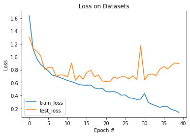

```python
# plot the training loss
plt.figure()
plt.plot(H["train_loss"], label="train_loss")
plt.plot(H["test_loss"], label="test_loss")
plt.title("Loss on Datasets")
plt.xlabel("Epoch #")
plt.ylabel("Loss")
plt.legend(loc="lower left")
plt.savefig(plot_path+str(startTime)+'result_loss.jpg')
# serialize the model to disk
```

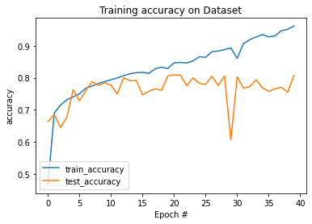

```python
# plot the training loss
plt.figure()
plt.plot(H["train_accuracy"], label="train_accuracy")
plt.plot(H["test_accuracy"], label="test_accuracy")
plt.title("Training accuracy on Dataset")
plt.xlabel("Epoch #")
plt.ylabel("accuracy")
plt.legend(loc="lower left")
plt.savefig(plot_path+str(startTime)+'result_accuracy.jpg')
```

```python
def visualize(satImage, trueImage, predImage):
    plt.figure(figsize=(16,16))

    plt.subplot(1, 3,  1)
    plt.title('Satellite image', fontsize=20)
    plt.imshow(satImage*0.5+0.5)

    output_true = np.zeros((crop_size, crop_size,3))
    for label, color in enumerate(colors):
      output_true[:,:,:][trueImage[:,:]==label] = color
    plt.subplot(1, 3, 2)
    plt.title("Groud Truth", fontsize=20)
    plt.imshow(output_true)

    output_pred = np.zeros((crop_size, crop_size,3))
    for label, color in enumerate(colors):
      output_pred[:,:,:][predImage[:,:]==label] = color
    plt.subplot(1, 3, 3)
    plt.title("Predicted image", fontsize=20)
    plt.imshow(output_pred)

    plt.show()
```

```
WARNING:matplotlib.image:Clipping input data to the valid range for imshow with RGB data ([0..1] for floats or [0..255] for integers).
WARNING:matplotlib.image:Clipping input data to the valid range for imshow with RGB data ([0..1] for floats or [0..255] for integers).
```

```
0.8328397274017334
27
```

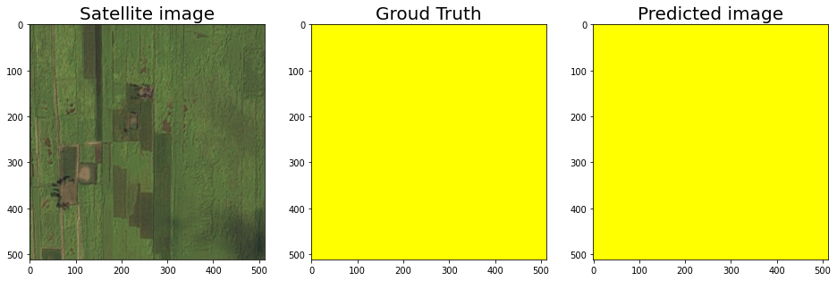

```
11
```

```
WARNING:matplotlib.image:Clipping input data to the valid range for imshow with RGB data ([0..1] for floats or [0..255] for integers).
WARNING:matplotlib.image:Clipping input data to the valid range for imshow with RGB data ([0..1] for floats or [0..255] for integers).
```

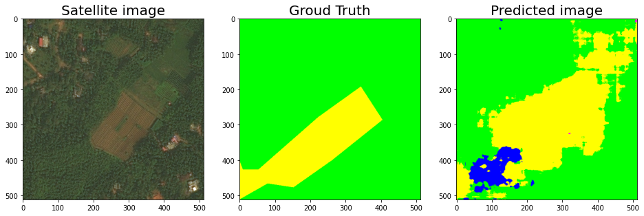

```
WARNING:matplotlib.image:Clipping input data to the valid range for imshow with RGB data ([0..1] for floats or [0..255] for integers).
WARNING:matplotlib.image:Clipping input data to the valid range for imshow with RGB data ([0..1] for floats or [0..255] for integers).
```

```
22
```

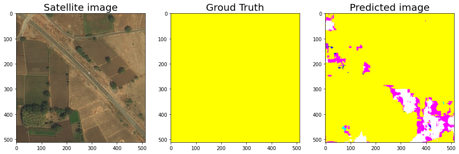

```
WARNING:matplotlib.image:Clipping input data to the valid range for imshow with RGB data ([0..1] for floats or [0..255] for integers).
WARNING:matplotlib.image:Clipping input data to the valid range for imshow with RGB data ([0..1] for floats or [0..255] for integers).
```

```
12
```

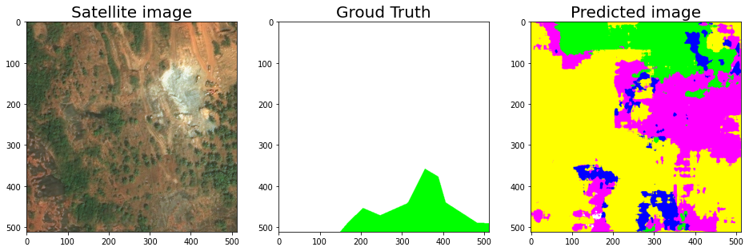

```
WARNING:matplotlib.image:Clipping input data to the valid range for imshow with RGB data ([0..1] for floats or [0..255] for integers).
WARNING:matplotlib.image:Clipping input data to the valid range for imshow with RGB data ([0..1] for floats or [0..255] for integers).
```

```
2
```

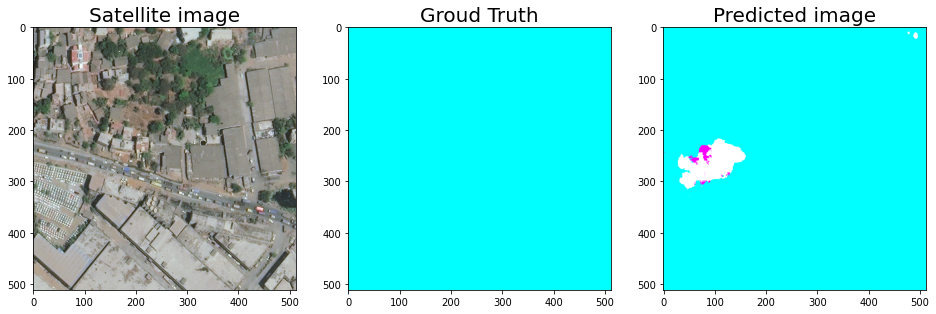

```python
for (i, (x, y)) in enumerate(testLoader):
  tmp_x = x.transpose(1,3).numpy()
  (x, y) = (x.to(device), y.to(device))

  pred = unet(x)
  y = y.detach().cpu().numpy()
  tmp_y = y

  pred = pred.detach().cpu().numpy()
  tmp_pred = np.argmax(pred, 1)

  accuracy = (tmp_y[:,:,:] == tmp_pred[:,:,:]).sum()/tmp_y.size
  print(accuracy)
  for j in (random.sample(range(tmp_x.shape[0]),5)):
    print(j)
    visualize(
    satImage = tmp_x[j],
    trueImage = tmp_y[j],
    predImage = tmp_pred[j]
    )

  break
```